# ASER variance over time

## District Data

We use ASER data from the ASER district pages from years 2006 to 2011. These are the only years for which ASER has publicly released district level data (to my knowledge). There are four learning outcomes variables which all of these district pages include:

- Share class 1 and 2 students who can at least read letters
- Share class 1 and 2 students who can at least recognize numbers
- Share class 3, 4, and 5 students who can at least read level 1 text
- Share class 3, 4, and 5 students who can at least do subtraction

Note that these figures averages across all children, regardless of what type of school they attend.

We use the last two learning outcomes – those for children in class 3, 4, and 5. These learning outcomes should be, in theory, more stable. In addition, they are similar to the learning outcome used in the ASER vs. NAS analysis.

## State Data

### ASER Trends over Time

Most of the analyses in this notebook are based on the ASER trends over time report. The ASER Trends over Time report includes ASER figures by state (and for the country as a whole) for the years 2006 to 2014. In particular, it includes the following data for the overall country and each state:

- Proportion boys, girls, and all children 6-14 enrolled in private school
- Proportion of boys, girls, and all children 6-14 not enrolled in any school
- Proportion 3rd graders who can read std 1 text by govt / private
- Proportion 5th graders who can read std 2 text by govt / private
- Proportion 3rd graders who do subtraction by govt / private
- Proportion 5th graders who do division text by govt / private
- English attainment for years 2007, 2009, 2012, and 2014 (but I haven’t yet processed and imported this data yet)

Of these, I used the ones for class 3 kids:

- share of class 3 kids who can read a std 1 text
- Share of class 3 kids who can do at least subtraction

```r
library(tidyverse)
output <- "C:/Users/dougj/Dropbox/Education in India/Original research/aservnas/figures"

dists <- read_csv("https://raw.githubusercontent.com/dougj892/public-datasets/master/aser_district_all_6.csv")
```

```r
states <- read_csv("https://raw.githubusercontent.com/dougj892/public-datasets/master/ASER%20trends%20over%20time.csv") %>%
  select(year, State, std3_read_std1_all, std3_subtract_all) %>%
  rename(std3_reading = std3_read_std1_all, std3_math = std3_subtract_all)
```

```r
##### IMPORTANT: TO DO ALL THE ANALYZE FOR MATH, SET THE SUBJECT BELOW TO "MATH" ###
subject <- "reading"
if (subject == "math") {
  dists$std35_std1_and_up <- dists$std35_subtraction_and_up
  states$std3_reading <- states$std3_math
}


### IMPORTANT -- THIS IS WHERE I SPECIFY DISTRICT SAMPLING VARIANCE ###
var_dist_sampling <- .0013
```

## District analysis

Estimate $corr(\Delta y_t , \Delta y_{t-1} )$ by using the autocorrelation of district deltas.

```r
# Create variable for deltas and first and second lag of the delta
dist_deltas <- dists %>%
  group_by(State, District) %>%
  mutate(delta_reading = std35_std1_and_up - lag(std35_std1_and_up, order_by = year), delta_math = std35_subtraction_and_up - lag(std35_subtraction_and_up)) %>%
  mutate(delta_reading_lagged = lag(delta_reading, order_by = year), delta_reading_dbl_lag = lag(delta_reading, n= 2, order_by = year)) %>%
  arrange(State, District, year)


# Calculate autocorrelation of delta_reading by district and then average over all districts
# Note that since the data is already grouped by State and district, we are calculating
# autocorrelation for each district and then averaging across all districts
corr_dist_deltas <- dist_deltas %>%
  filter(year >= 2008) %>%
  summarise(auto = cor(delta_reading, delta_reading_lagged)) %>%
  ungroup() %>%
  summarise(mean_auto=mean(auto)) %>% .$mean_auto
# Calculate the autocorrelation in one go for all pairs of delta and delta_lagged.
# Note that we are not doing any averaging here.
# This should spit out a very similar value and it does.
check_corr_dist_deltas <- dist_deltas %>%
  ungroup() %>%
  filter(year >= 2008) %>%
  summarise(auto = cor(delta_reading, delta_reading_lagged))


# Calculate the overall variance of the deltas
# Note that we have to divide by 100 here to get the actual number.
# We didn't need to do this above because we just calculated correlation and thus scale didn't matter
var_dist_deltas <- var(dist_deltas$delta_reading/100, na.rm = TRUE)

# Calculate overall variance of the district values.
# Note that we don't want to first calculate variance of dist reading scores by state and then average
# That would really underestimate the variance of the district scores.
# (To understand intuition, note districts are considered iid in the model above.)
var_dist_levels <- var(dists$std35_std1_and_up/100, na.rm = TRUE)

# Calculate variance of the transitory component
var_dist_epsilon <- -corr_dist_deltas*var_dist_deltas
```

Check that $corr(\Delta y_t , \Delta y_{t-2} )=0$ and that letters and numbers are correlated.

```r
#
corr_dist_dbl_lag <- dist_deltas %>% filter(year >= 2009) %>%
  ungroup() %>%
  summarize(auto =cor(delta_reading,delta_reading_dbl_lag, use = "pairwise.complete.obs")) %>%
  .$auto


# Check that changes in letters and numbers is correlated -- they are
dist_deltas %>% filter(year != 2006) %>% ungroup() %>%
  summarize(cor(delta_reading,delta_math))
```

| cor(delta_reading, delta_math) |
| --- |
| 0.7550424 |

```r
NA
```

### Consolidated district level results

Based on the code above, the final values for the key parameters for the district level are…

- $corr(\Delta y_t , \Delta y_{t-1} ) = -0.4403591$
- $Var(\Delta y_t )= 0.0155017$
- $\sigma^2_{\varepsilon} = -corr(\Delta y_t , \Delta y_{t-1} )* Var(\Delta y_t ) = 0.0068263$
- $\sigma^2_y = 0.0242021$

From these figures, we can calculate:

- Share of variance in **levels** due to transitory shocks = 0.282055
- Share of variance in **changes** due to transitory shocks = 0.8807182
- Share of the transitory variance due to sampling (for both changes and levels) = 0.1904393

## State analysis - method 1

Estimate $corr(\Delta y_t , \Delta y_{t-1} )$ at state level by average autocorrelation of state deltas.

```r
# Create variable for year on year change for each district
state_deltas <- states %>%
  group_by(State) %>%
  mutate(delta_reading = std3_reading - lag(std3_reading, order_by = year), delta_math = std3_math - lag(std3_math, order_by = year)) %>%
  mutate(delta_reading_lagged = lag(delta_reading, order_by = year), delta_reading_dbl_lag = lag(delta_reading,n=2, order_by = year)) %>%
  arrange(State, year)


# Calculate average autocorrelation of delta_reading
corr_state_deltas <- state_deltas %>%
  filter(year >= 2008) %>%
  summarise(auto = cor(delta_reading, delta_reading_lagged, use = "pairwise.complete.obs")) %>%
  ungroup() %>%
  summarise(mean_auto=mean(auto)) %>% .$mean_auto
# Calculate correlation betwen delta letters and delta letters lagged for entire dataset (without first calculating for each state and then averaging).
# this should be about the same as when we first calculate for each state and then average --> which it is.
check_corr_state_deltas <- state_deltas %>% filter(year >= 2008) %>%
  ungroup() %>%
  summarize(auto =cor(delta_reading,delta_reading_lagged, use = "pairwise.complete.obs")) %>%
  .$auto


# calculate the variance of the deltas
var_state_deltas <- var(state_deltas$delta_reading, na.rm = TRUE)

# calculate the variance of the levels
var_state_levels <- var(state_deltas$std3_reading, na.rm = TRUE)

# calculate variance of transitory component
var_state_epsilon <- -corr_state_deltas*var_state_deltas
```

Calculate average sampling variance. Note that since we are just calculating the overall average, I don’t have to merge on state names.

```r
var_state_sampling <- dists %>% filter(year ==2008) %>%
  count(State) %>%
  mutate(sampling_var = var_dist_sampling/n) %>%
  summarize(mean_sampling = mean(sampling_var)) %>% .$mean_sampling
```

check that there is no correlation with double lags

```r
# Check that changes in letters and numbers is correlated -- they are highly correlated
state_deltas %>% filter(year >= 2008) %>% ungroup() %>%
  summarize(cor(delta_reading,delta_math, use = "pairwise.complete.obs"))
```

| cor(delta_reading, delta_math, use = "pairwise.complete.obs") |
| --- |
| 0.6963405 |

```r
corr_state_dbl_lag <- state_deltas %>% filter(year >= 2009) %>%
  ungroup() %>%
  summarize(auto =cor(delta_reading,delta_reading_dbl_lag, use = "pairwise.complete.obs")) %>%
  .$auto


temp <- state_deltas %>% filter(year >= 2009) %>%
  group_by(State) %>%
  summarize(auto =cor(delta_reading,delta_reading_dbl_lag, use = "pairwise.complete.obs"))
```

### Consolidated state level results - method 1

Since the correlation of current levels and twice lags is not 0, we don’t use these values, but consolidating them here for reference:

- $corr(\Delta y_t , \Delta y_{t-1} ) = -0.2633612$
- $Var(\Delta y_t )= 0.0062517$
- $\sigma^2_{\varepsilon} = -corr(\Delta y_t , \Delta y_{t-1} )* Var(\Delta y_t ) = 0.0016465$
- $\sigma^2_y = 0.0187031$
- $\sigma^2_{sampling} = 2.0805248\times 10^{-4}$

## State analysis - method 2

Calculate the share of variance due to persistent effects by look at how correlation in levels decays over time. Note that I could theoretically calculate more lags (since the state data is for 2006 to 2014) but then each lag would be specific to a single year (e.g. 2009-2008) rather than multiple years (the average of 2014-2013, 2013-2012, etc).

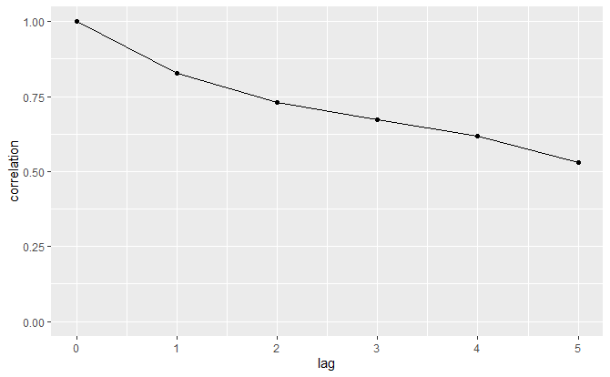

```r
state_lags <- states %>%
  group_by(State) %>%
  mutate(read_lag1 = lag(std3_reading, order_by = year),
         read_lag2 = lag(std3_reading, n= 2, order_by = year),
         read_lag3 = lag(std3_reading, n =3, order_by = year),
         read_lag4 = lag(std3_reading, n =4, order_by = year),
         read_lag5 = lag(std3_reading, n =5, order_by = year)) %>%
  ungroup()

rho = c()
# for each of the lags, calculate the correlation between current and the lag and store in vector rho
for (lag in seq(1,5)) {
  rho <- c(rho, cor(state_lags$std3_reading, state_lags[[paste("read_lag",as.character(lag),sep="")]], use = "pairwise.complete.obs"))
}
# Calculate variance of the transitory component by comparing rho_1 with the decay of rho after that
var_state_levels_persistent2 <- rho[1]/mean(rho/lag(rho), na.rm = TRUE)*var_state_levels

# Calculate the share of variance coming from other transitory sources.
# We will need this to calculate the variance breakup for changes
var_state_levels_other2 <- var_state_levels - var_state_levels_persistent2 - var_state_sampling

# Save a graph showing the decay of the correlation
quick_df <- tibble(lag = seq(0,5), correlation = c(1,rho))
ggplot(quick_df, aes(x= lag, y = correlation)) +
  geom_line() +
  geom_point() +
  ylim(0,1)

ggsave(paste(subject, "- correlation_decay.png"), width = 5, height = 6 , path = output)
```

### Consolidated state level results - method 2

With method 2, we have the same values for * $Var(\Delta y_t )$,$\sigma^2_y$, and $\sigma^2_{sampling}$.

Instead of calculating $\sigma^2_{\varepsilon}$, we calculate…

- $\sigma^2_{pers} = 0.0173179$

And then use these values to calculate…

- Share of variance in **levels** due to transitory shocks = 0.0740615
- Share of variance in **changes** due to transitory shocks = 0.4431375
- Share of the transitory variance due to sampling (for both changes and levels) = 0.1501987

### Create bar plot of results

We now have all the inputs we need to replicate figure 4 from Kane and Staiger

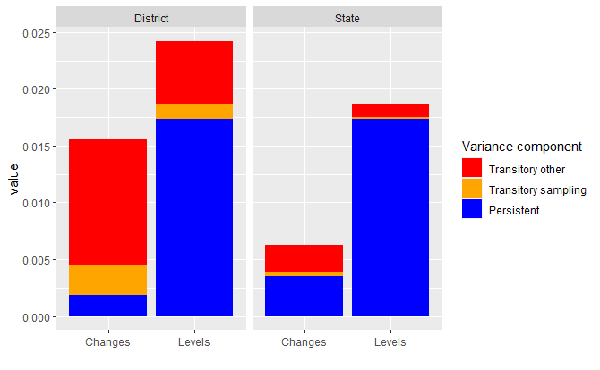

```r
# Create empty tibble to store results
# I
df_bar <- tibble(state_or_dist = rep(c("State","District"),each =6),
                 changes_or_levels =rep(rep(c("Changes","Levels"), each =3), times= 2),
                 bar_part = factor(rep(c("Persistent","Transitory sampling", "Transitory other"),4), levels = c("Transitory other","Transitory sampling", "Persistent")),
                 value = rep(.001,12)
                 )
# Update the values for the district changes bar
df_bar$value[(df_bar$state_or_dist == "District") & (df_bar$changes_or_levels == "Changes") & (df_bar$bar_part == "Persistent")] <- var_dist_deltas - 2*var_dist_epsilon

df_bar$value[(df_bar$state_or_dist == "District") & (df_bar$changes_or_levels == "Changes") & (df_bar$bar_part == "Transitory sampling")] <- 2*var_dist_sampling

df_bar$value[(df_bar$state_or_dist == "District") & (df_bar$changes_or_levels == "Changes") & (df_bar$bar_part == "Transitory other")] <- 2*var_dist_epsilon - 2*var_dist_sampling


# Update the values for the district levels bar
df_bar$value[(df_bar$state_or_dist == "District") & (df_bar$changes_or_levels == "Levels") & (df_bar$bar_part == "Persistent")] <- var_dist_levels - var_dist_epsilon

df_bar$value[(df_bar$state_or_dist == "District") & (df_bar$changes_or_levels == "Levels") & (df_bar$bar_part == "Transitory sampling")] <- var_dist_sampling

df_bar$value[(df_bar$state_or_dist == "District") & (df_bar$changes_or_levels == "Levels") & (df_bar$bar_part == "Transitory other")] <- var_dist_epsilon - var_dist_sampling

##### STATE DATA #####

# CHANGES
df_bar$value[(df_bar$state_or_dist == "State") & (df_bar$changes_or_levels == "Changes") & (df_bar$bar_part == "Persistent")] <- var_state_deltas-2*(var_state_sampling+var_state_levels_other2)

df_bar$value[(df_bar$state_or_dist == "State") & (df_bar$changes_or_levels == "Changes") & (df_bar$bar_part == "Transitory sampling")] <- 2*var_state_sampling

df_bar$value[(df_bar$state_or_dist == "State") & (df_bar$changes_or_levels == "Changes") & (df_bar$bar_part == "Transitory other")] <- 2*var_state_levels_other2


# LEVELS
df_bar$value[(df_bar$state_or_dist == "State") & (df_bar$changes_or_levels == "Levels") & (df_bar$bar_part == "Persistent")] <- var_state_levels_persistent2

df_bar$value[(df_bar$state_or_dist == "State") & (df_bar$changes_or_levels == "Levels") & (df_bar$bar_part == "Transitory sampling")] <- var_state_sampling

df_bar$value[(df_bar$state_or_dist == "State") & (df_bar$changes_or_levels == "Levels") & (df_bar$bar_part == "Transitory other")] <- var_state_levels_other2


# I have created this graph so that you can see it in the notebook
# The final version which combines both subjects, is created in a separate notebook
ggplot(df_bar, aes(fill = bar_part, y=value, x= changes_or_levels)) +
  geom_bar(position="stack", stat ="identity") +
  facet_grid(~ state_or_dist) +
  scale_fill_manual(values = c("red", "orange", "blue"))+
  labs(fill = "Variance component", x = "")

ggsave(paste(subject," - variance_decomposition.png"), width = 5, height = 6 , path = output)
```

```r
write_csv(df_bar, file.path(output, paste(subject, "- bar data.csv")))
```

### Create dataframe with results

Take the output that was used to create the bar graph, reshape it, and save it as a csv

```r
df_final <- df_bar %>%
  pivot_wider(names_from = "bar_part", values_from= "value") %>%
  mutate(total_var = `Persistent`+`Transitory sampling`+`Transitory other`) %>%
  mutate(share_pers = `Persistent`/total_var, share_samp = `Transitory sampling`/total_var, share_other = `Transitory other`/total_var)

write_csv(df_final, file.path(output, paste(subject, "- var deco.csv")))
```